# Tipos de filmes de Emma Watson.

Valter Lucena

24 de junho de 2018

A atriz *Emma Watson* ficou conhecida mundialmente ao interpretar a personagem **Hermione Granger** nos filmes da saga *Harry Potter*. A fama alcançada pelo sucesso da saga possibilitou que a atriz atuasse em diversos outros filmes. Mesmo que nem todos esses filmes tenham feito tanto sucesso como a saga *Harry Potter*, eles permitiram que a atriz mostrasse que consegue interpretar outros papéis.

O site [Rotten Tomatoes](https://www.rottentomatoes.com) reúne informações sobre as avaliações e bilheteria dos filmes onde diversos autores atuaram, incluindo os de Emma. A partir dessas informações, vamos classificar os tipos de filmes da atriz Emma Watson.

```r
import_data(celebridade = "emma_watson")
filmes = read_imported_data()
```

Observemos, agora, sobre o que se tratam os dados que reunimos.

```r
names(filmes)
```

```
## [1] "avaliacao"  "filme"      "papel"      "bilheteria" "ano"
```

- `avaliacao`: a nota que o *Rotten* atribui a um filme.
- `filme`: o título do filme.
- `papel`: o papel representado.
- `bilheteria`: o valor arrecadado pelo filme.
- `ano`: o ano de lançamento do filme.

Uma visualização dos dados permite que identifiquemos determinadas curiosidades que não conseguiríamos observando apenas os valores na tabela com todas as observações. Portanto, vamos observar, através de um *scatter plot*, como se relacionam as variávies `avaliacao` e `bilheteria`. Cada ponto no gráfico refere-se à um filme, e mais informações sobre o filme podem ser vistas passando o mouse sobre eles.

```r
plot_ly(data = filmes,
        x = filmes$avaliacao,
        y = filmes$bilheteria,
        text = ~paste("Filme: ", filme,
                      "<br>Papel: ", papel ),
        type = 'scatter') %>%
    layout(title = "",
        xaxis = list(title = "Avaliação",
                     titlefont = list(size = 12)),
        yaxis = list(title = "Bilheteria (milhões de dólares)",
                     titlefont = list(size = 12)))
```

[interactive chart not shown]

Podemos observar, a partir do gráfico, que alguns dos filmes possuem valores parecidos para avaliação e bilheteria. Vamos usar isso em nosso favor e agrupar os filmes que possuem características semalhantes para determinar os tipos de filmes da atriz.

Agruparemos esses dados utilizando o método **euclidiano**, que agrupa dados calculando as distâncias entre os pontos do gráfico, onde pontos muitos próximos serão colocados no mesmo grupo.

Utilizando um dendrograma, podemos visualizar em quantos grupos podemos separar os filmes.

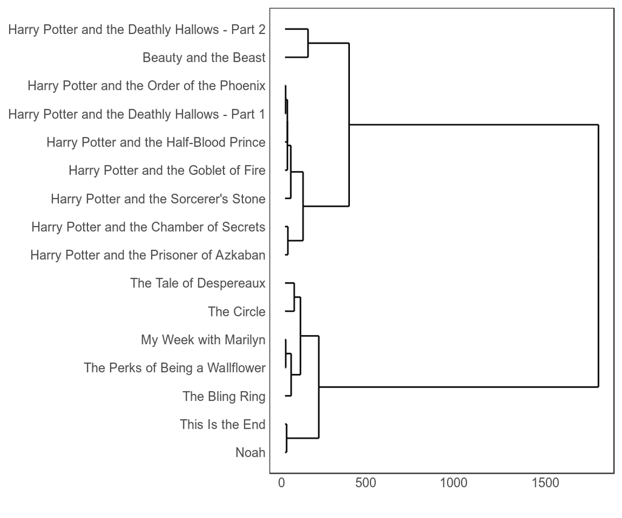

```r
agrupamento_h_2d = filmes %>%
    column_to_rownames("filme") %>%
    select(avaliacao, bilheteria) %>%
    dist(method = "euclidean") %>%
    hclust(method = "ward.D")

ggdendrogram(agrupamento_h_2d, rotate = TRUE)
```

Neste dendrograma, observamos que o algoritmo inicia agrupando dois filmes, juntando outro filme neste agrupamento, e assim por diante. Antes do fim do algoritmo, podemos observar que existem 3 ramos de filmes agrupados. A partir disto, poderíamos assumir que 3 grupos seriam bons para classificar os filmes.

Como os valores de bilheteria estão na ordem de milhões de dólares, e as avaliações vão no máximo até uma centena, vamos utilizar a escala logarítmica na bilheteria a fim de diminuir a diferença entre as escalas para verificar se 3 seria um bom número de grupos.

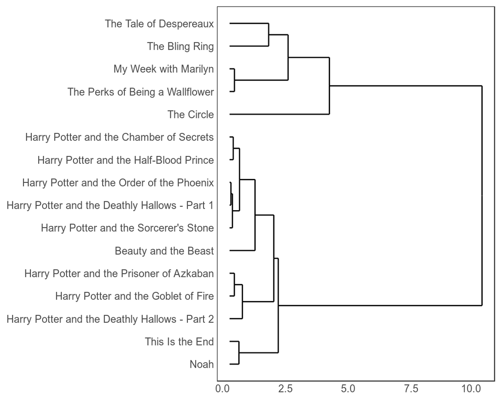

```r
agrupamento_h_2d = filmes %>%
    mutate(bilheteria = log10(bilheteria)) %>%
    mutate_at(vars("avaliacao", "bilheteria"), funs(scale)) %>%
    column_to_rownames("filme") %>%
    select("avaliacao", "bilheteria") %>%
    dist(method = "euclidean") %>%
    hclust(method = "ward.D")

ggdendrogram(agrupamento_h_2d, rotate = TRUE)
```

Em escala logarítmica, é possível observar que existem 4 ramos antes do algortimo terminar. Num *scatter plot*:

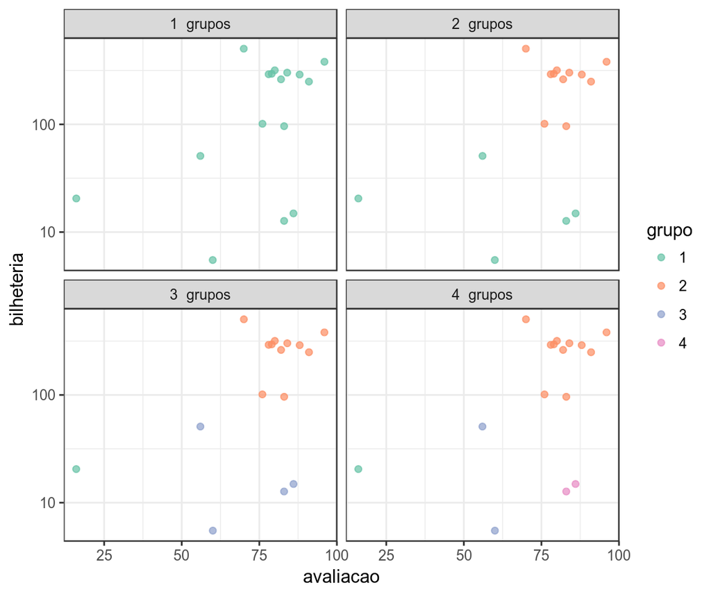

```r
filmes2 = filmes %>%
  mutate(bilheteria = log10(bilheteria))

plota_hclusts_2d(agrupamento_h_2d,
                 filmes2,
                 c("avaliacao", "bilheteria"),
                 linkage_method = "ward.D",
                 ks = 1:4) +
  scale_y_log10()
```

Percebemos aqui que, utilizando 3 grupos, as observações do grupo azul visualmente ainda estão um pouco distantes, e que com 4 grupos a divisão faz mais sentido, já que o novo grupo rosa encontra-se numa faixa diferente de avaliação que os do grupo azul.

Assim, podemos dividir os filmes da atriz *Emma Watson* em 4 tipos diferentes:

- **Hits**: os filmes deste tipo, identificados pela cor laranja, são os filmes que obtiveram sucesso tanto em crítica como em bilheteria. Neste grupo estão inclusos os filmes da saga *Harry Potter*, e o *live action* do clássico infatil da *Disney*, *Beauty and the Beast*, onde Emma foi protagonista.
- **Cults**: identificados pela cor rosa, aqui se encontram os filmes que não obtiveram tanto sucesso de bilheteria, mas agradaram os críticos. Este grupo contém o filme *The perks of being a wallflower*, adaptação de um livro do mesmo nome, que ficou popular entre os cinéfilos.
- **Flat**: o grupo roxo é formado por filmes que não agradaram muito os críticos, com uma bilheteria morna. O filme *The Bling Ring*, que conta a história de uma gangue de adolescentes de classe média que furtavam a casa de celebridades, pertence à este grupo.
- **Flop**: O pontinho verde solitário no gráfico representa um filme que não agradou muito o público, e não agradou em nada os críticos.